# Exoplanets

### An Exoplanet is a planet that orbits a different star than our sun, and thus is outside of our solarsytem.

### Exoplanets have long captivated the imagination of SciFi writers and readers alike, but until relatively recently, we didn't even know whether other stars but our own had planets orbiting around them, and if so, how common they were.

### The first exoplanet candidate was described in 1989, and since then the rate of detection has increased significantly.

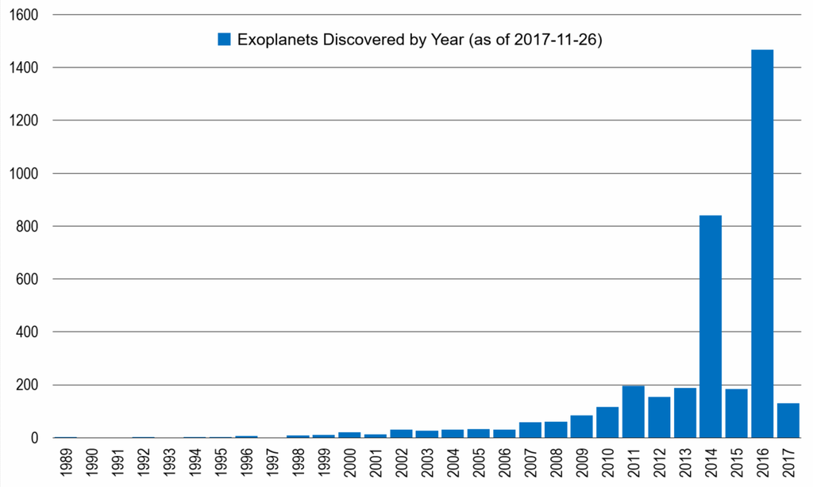

```python
path = %pwd
from IPython.display import Image
Image(filename = path+'/Histogram_Chart_of_Discovered_Exoplanets_as_of_2017-11-26.png')
# data from Exoplanet.eu, via Wikipedia
```

```python
Image(url = 'https://imgs.xkcd.com/comics/exoplanets.png') # from XKCD 1071
```

[figure not shown]

[figure not shown]

```python
Image(filename = path+'/exoplanets_large_zoom.png')
```

### Of course someone has made an interactive version of this chart, which can be found on [github](https://github.com/codementum/exoplanets)

# Exoplanet archives

### There are many exoplanet archives, and for no other reason than that their data was easily accessible as .csv, I chose the [NASA Exoplanet Archive](https://exoplanetarchive.ipac.caltech.edu/docs/intro.html) hosted on the CalTech website.

## I had no particular goal in mind, other than that I was excited about exoplanets and wanted to know where we are with this now, and how soon I can move to Vulcan.

### Since I first downloaded this table a few weeks ago, 17 new planets have been added to the archive.

```python
## importing the relevant and not relevant packages
import numpy as np
import pandas as pd
import matplotlib.pyplot as plt
import matplotlib.axes as ax
import seaborn as sns
import re
from ipywidgets import widgets
from ipywidgets import interact
from sklearn.ensemble import RandomForestClassifier

# import random
# random.seed(12345)
```

```python
## reading the data from the csv-file

planets = pd.read_csv('planets.csv', index_col=0, header=73)
```

```python
planets.shape
```

```
(3564, 69)
```

### The data-table in its current format contains 3564 planets, with 69 feature columns (like distance from earth, planet mass, orbital period...)

### not every feature is known for every planet, and not every feature is particularly useful to know

```python
## reducing the number of feature columns

# Deleting columns that, instead of a unique feature, contain the measurement errors of another feature
for i in planets.dtypes.index:
    if re.findall(r"err",i) != []:
        del planets[i]

# Calculating the percent missing values(NaN) for each column
nan = planets.isnull().sum()/len(planets)*100

# Deleting columns with too many missing values (cutoff is 75%)
before=planets.shape
for i in range(len(nan)):
    if nan[i]>75.0:
#         print(nan.index[i]+'  '+str(nan[i]))
        del planets[nan.index[i]]
after=planets.shape
```

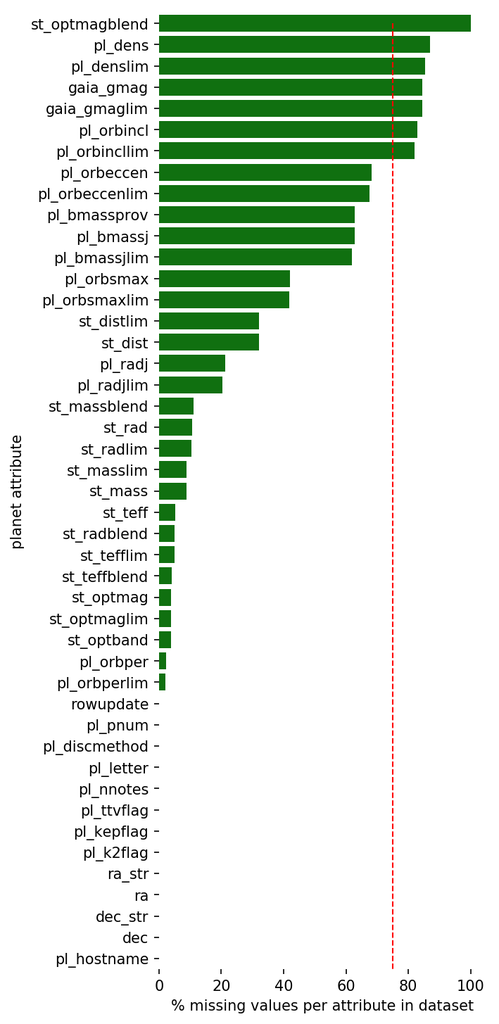

```
7 out of 45 attributes have been removed from the dataset because they contained too many missing values

The final DataFrame has the following dimensions: 3564 discovered planets, with 38 recorded features
```

```python
### Plotting NaN counts
nan_sorted = nan.sort_values(ascending=False).to_frame().reset_index()
nan_sorted.columns = ['Column', 'percentNaN']

fig, ax = plt.subplots(figsize=(4,12), dpi=150)
sns.barplot(x="percentNaN", y="Column", data=nan_sorted, color='Green', ax=ax)
ax.set(xlabel="% missing values per attribute in dataset", ylabel="planet attribute")
sns.despine(left=True, bottom=True)
plt.plot([75, 75], [0,70], linewidth=1, ls='--', c='r')
plt.show()

print(str(before[1]-after[1])+' out of '+str(before[1])+' attributes have been removed from the dataset because they contained too many missing values')
print('\nThe final DataFrame has the following dimensions: '+str(planets.shape[0])+' discovered planets, with '+str(planets.shape[1])+' recorded features')
```

## Exoplanets can be detected using various different methods, some of which are more common than others.

### By far the most common methods are:

### The Transit method

```python
Image(url = 'https://archive.stsci.edu/prepds/kepler_hlsp/KeplerLightCurves.png')
```

[figure not shown]

### and the Radial velocity method:

```python
# Image(url = 'https://upload.wikimedia.org/wikipedia/commons/3/3a/18_Del_b_rv.pdf')
Image(url = 'https://upload.wikimedia.org/wikipedia/commons/3/33/ESO_-_The_Radial_Velocity_Method_%28by%29.jpg')
```

[figure not shown]

```python
# Turning the names for discovery methods into integers, with the following code
    # 1 = Astrometry
    # 2 = Eclipse Timing Variations
    # 3 = Imaging
    # 4 = Microlensing
    # 5 = Orbital Brightness Modulation
    # 6 = Pulsar Timing
    # 7 = Pulsation Timing Variations
    # 8 = Radial Velocity
    # 9 = Transit
    # 10 = Transit Timing Variations

method_code=[]
for i in planets['pl_discmethod']:
    if i == 'Astrometry':
        method_code.append(1)
    elif i == 'Eclipse Timing Variations':
        method_code.append(2)
    elif i == 'Imaging':
        method_code.append(3)
    elif i == 'Microlensing':
        method_code.append(4)
    elif i == 'Orbital Brightness Modulation':
        method_code.append(5)
    elif i == 'Pulsar Timing':
        method_code.append(6)
    elif i == 'Pulsation Timing Variations':
        method_code.append(7)
    elif i == 'Radial Velocity':
        method_code.append(8)
    elif i == 'Transit':
        method_code.append(9)
    elif i == 'Transit Timing Variations':
        method_code.append(10)

## add a feature column "method_code" to the DataFrame
planets['method_code']=method_code
planets['pred_target']=method_code

## Creating a new DataFrame with the method code as the index column
planets = planets.set_index(['method_code'])
```

```python
## filling-in missing values in the remaining columns with median
# for that purpose I am splitting the df into several different dataframes (one for each detection method)
# and fill in missing values in columns with the median for that particular column. Without splitting (and more
# knowledge of coding), the missing values would be replaced with overall median per column
# (independent of detection method)

df1 = planets.loc[[1],:]
median_values = df1.median(axis=0)
df1 = df1.fillna(median_values, inplace=True)

df2 = planets.loc[[2],:]
median_values = df2.median(axis=0)
df2 = df2.fillna(median_values, inplace=True)

df3 = planets.loc[[3],:]
median_values = df3.median(axis=0)
df3 = df3.fillna(median_values, inplace=True)

df4 = planets.loc[[4],:]
median_values = df4.median(axis=0)
df4 = df4.fillna(median_values, inplace=True)

df5 = planets.loc[[5],:]
median_values = df5.median(axis=0)
df5 = df5.fillna(median_values, inplace=True)

df6 = planets.loc[[6],:]
median_values = df6.median(axis=0)
df6 = df6.fillna(median_values, inplace=True)

df7 = planets.loc[[7],:]
median_values = df7.median(axis=0)
df7 = df7.fillna(median_values, inplace=True)

df8 = planets.loc[[8],:]
median_values = df8.median(axis=0)
df8 = df8.fillna(median_values, inplace=True)

df9 = planets.loc[[9],:]
median_values = df9.median(axis=0)
df9 = df9.fillna(median_values, inplace=True)

df10 = planets.loc[[10],:]
median_values = df10.median(axis=0)
df10 = df10.fillna(median_values, inplace=True)

# putting all median-imputed DataFrames back together into one DataFrame
frames = [df1, df2, df3, df4, df5, df6, df7, df8, df9, df10]
planets = pd.concat(frames)
```

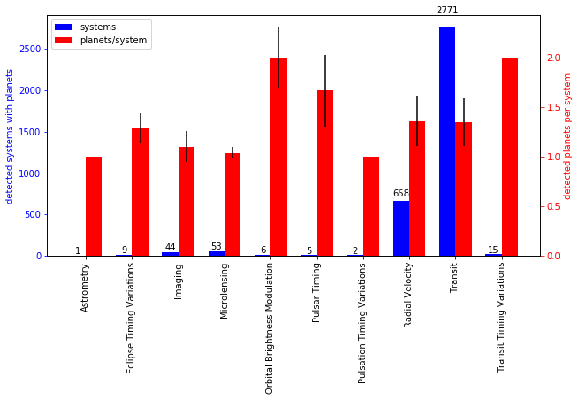

```python
"""
=======================================
Comparing discovery methods for the number of systems they discovered and the number of planets per system
=======================================
"""

#################
# changing the dataframe to be limited to star systems with unique host star names, to calculate the number of planets per star system
un_hoststars=planets.drop_duplicates(subset='pl_hostname')

#################
## counting the number of systems with at least one planet that were detected with a given detection method
un_methods=[]
un_methods_pcount=[]
methods=np.array(planets.loc[:,'pl_discmethod'])
un_methods=(np.unique(methods))
np.delete(un_methods,2)
for i in range(len(un_methods)):
    un_methods_pcount.append(len(planets[(planets['pl_discmethod']==un_methods[i])]))
#################


## counting the number of planets around each star that were detected with a given detection method and calculating the mean number of planets per method
Astrometry_num=un_hoststars.loc[lambda df: un_hoststars.pl_discmethod == 'Astrometry', :]
mean_Astrometry_num=np.mean(Astrometry_num.iloc[:,3])

ETV_num=un_hoststars.loc[lambda df: un_hoststars.pl_discmethod == 'Eclipse Timing Variations', :]
mean_ETV_num=np.mean(ETV_num.iloc[:,3])

Imaging_num=un_hoststars.loc[lambda df: un_hoststars.pl_discmethod == 'Imaging', :]
mean_Imaging_num=np.mean(Imaging_num.iloc[:,3])

Microlensing_num=un_hoststars.loc[lambda df: un_hoststars.pl_discmethod == 'Microlensing', :]
mean_Microlensing_num=np.mean(Microlensing_num.iloc[:,3])

OBM_num=un_hoststars.loc[lambda df: un_hoststars.pl_discmethod == 'Orbital Brightness Modulation', :]
mean_OBM_num=np.mean(OBM_num.iloc[:,3])

PulsarT_num=un_hoststars.loc[lambda df: un_hoststars.pl_discmethod == 'Pulsar Timing', :]
mean_PulsarT_num=np.mean(PulsarT_num.iloc[:,3])

PTV_num=un_hoststars.loc[lambda df: un_hoststars.pl_discmethod == 'Pulsation Timing Variations', :]
mean_PTV_num=np.mean(PTV_num.iloc[:,3])

RV_num=un_hoststars.loc[lambda df: un_hoststars.pl_discmethod == 'Radial Velocity', :]
mean_RV_num=np.mean(RV_num.iloc[:,3])

Transit_num=un_hoststars.loc[lambda df: un_hoststars.pl_discmethod == 'Transit', :]
mean_Transit_num=np.mean(Transit_num.iloc[:,3])

TTV_num=un_hoststars.loc[lambda df: un_hoststars.pl_discmethod == 'Transit Timing Variations', :]
mean_TTV_num=np.mean(TTV_num.iloc[:,3])

# numbers of planets detected with each method
planet_numbers=[Astrometry_num.iloc[:,3],ETV_num.iloc[:,3],Imaging_num.iloc[:,3],Microlensing_num.iloc[:,3],OBM_num.iloc[:,3],PulsarT_num.iloc[:,3],PTV_num.iloc[:,3],RV_num.iloc[:,3],Transit_num.iloc[:,3],TTV_num.iloc[:,3]]

# average number of planets detected with each method
mean_planet_numbers=[mean_Astrometry_num,mean_ETV_num,mean_Imaging_num,mean_Microlensing_num,mean_OBM_num,mean_PulsarT_num,mean_PTV_num,mean_RV_num,mean_Transit_num,mean_TTV_num]

# standard error of the mean (SEM) for number of un_hoststars detected with each method
planet_numbers_SEM=[]
for i in range(len(planet_numbers)):
    planet_numbers_SEM.append((np.std(planet_numbers[i], ddof=1))/np.sqrt(len(planet_numbers)))
#################

#################
## plotting both the number of detected systems and the average number of detected planets/system for each method
x_indexes = np.arange(len(planet_numbers))  # the x locations for the groups
bar_width = 0.35        # the width of the bars

fig, ax1 = plt.subplots(figsize=(10, 5))
rects1 = ax1.bar(x_indexes, un_methods_pcount, bar_width, color='b')
ax2 = ax1.twinx()
rects2 = ax2.bar(x_indexes + bar_width, mean_planet_numbers, bar_width, color='r', yerr=planet_numbers_SEM)

# add some text for labels, title and axes ticks
ax1.set_ylabel('detected systems with planets', color='b')
ax1.tick_params('y', colors='b')
ax2.set_ylabel('detected planets per system', color='r')
ax2.tick_params('y', colors='r')
ax1.set_xticks(x_indexes + bar_width / 2)
ax1.set_xticklabels(un_methods, rotation=90)

ax1.legend((rects1[0], rects2[0]), ('systems', 'planets/system'))

def autolabel(rects): # Attach a text label above each bar displaying its height
    for rect in rects:
        height = rect.get_height()
        ax1.text(rect.get_x() + rect.get_width()/2., 1.05*height,'%d' % int(height),ha='center', va='bottom')

autolabel(rects1)
autolabel(rects2)

plt.show()
#################
```

## Some detection methods clearly are more comon than others. Four methods are responsible for 99% of detected exoplanets.

### So I decided to remove the other methods from the dataset.

```python
## Limiting the dataset to the four most often used methods for planet detection
red_planets = planets.loc[[3,4,8,9],:]
removed=len(planets.loc[[1]])+len(planets.loc[[2]])+len(planets.loc[[5]])+len(planets.loc[[6]])+len(planets.loc[[7]])+len(planets.loc[[10]])
print('\n'+str(removed)+' planets have been removed from the dataset, \nand the final DataFrame has the following dimensions: '+str(red_planets.shape[0])+' discovered planets, with '+str(red_planets.shape[1])+' recorded features')
```

```
38 planets have been removed from the dataset,
and the final DataFrame has the following dimensions: 3526 discovered planets, with 39 recorded features
```

### The 'pairplot' function of Seaborn is very useful for initial data analysis. However...

```python
# g = sns.pairplot(red_planets, hue='pl_discmethod')
# plt.show(g)
```

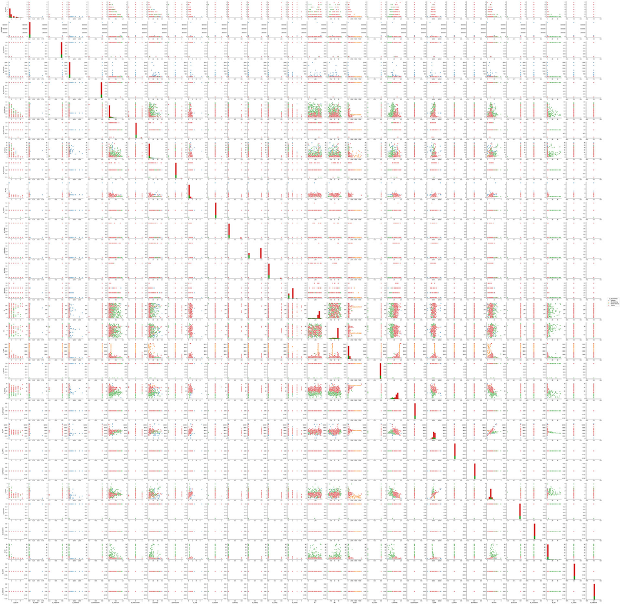

```python
Image(filename = path+'/pairplot_downsized.jpg')
```

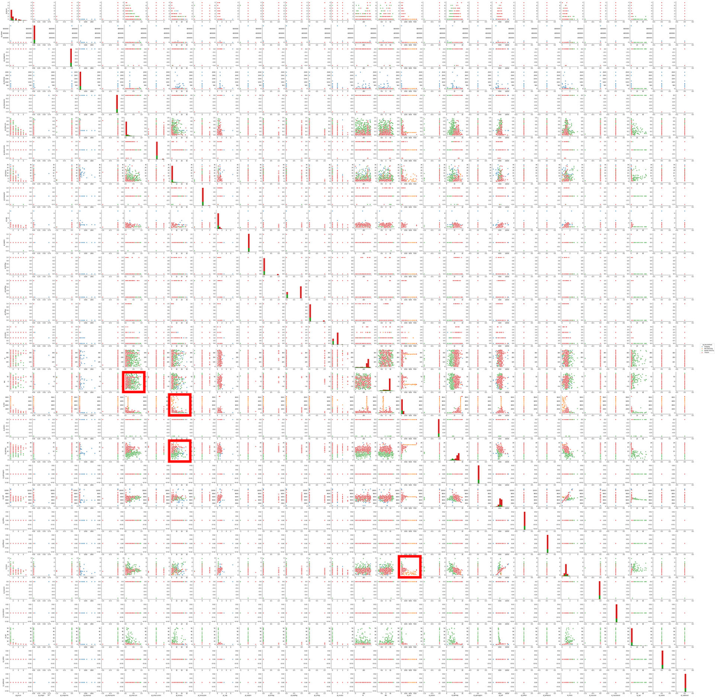

```python
Image(filename = path+'/pairplot_annotated_downsized.jpg')
```

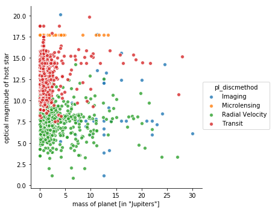

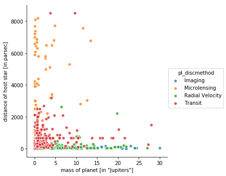

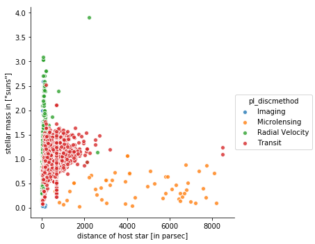

```python
DataFrame_features={'features':['pl_hostname', 'pl_letter', 'pl_discmethod', 'pl_pnum', 'pl_orbper',
       'pl_orbperlim', 'pl_orbsmax', 'pl_orbsmaxlim', 'pl_orbeccen',
       'pl_orbeccenlim', 'pl_bmassj', 'pl_bmassjlim', 'pl_bmassprov',
       'pl_radj', 'pl_radjlim', 'pl_ttvflag', 'pl_kepflag', 'pl_k2flag',
       'pl_nnotes', 'ra_str', 'ra', 'dec_str', 'dec', 'st_dist', 'st_distlim',
       'st_optmag', 'st_optmaglim', 'st_optband', 'st_teff', 'st_tefflim',
       'st_teffblend', 'st_mass', 'st_masslim', 'st_massblend', 'st_rad',
       'st_radlim', 'st_radblend', 'rowupdate']}

axis_labels={'dec':'declination of planetary system', 'pl_orbeccen':'orbital eccentricity of the planet',
          'pl_bmassj':'mass of planet [in "Jupiters"]', 'pl_orbper':'orbital period of the planet [in days]',
            'pl_radj':'radius of planet [in "Jupiters"]', 'st_optmag':'optical magnitude of host star',
            'st_dist':'distance of host star [in parsec]', 'st_mass':'stellar mass in ["suns"]'}

def select_x_feature(x_feature):
    global xf
    xf = x_feature

def select_y_feature(y_feature):
    global yf
    yf = y_feature

def on_button_clicked(b):
    g = sns.lmplot(data=red_planets, x=xf, y=yf , fit_reg=False, hue='pl_discmethod',scatter_kws={'linewidths':1,'edgecolor':'w'})
    g.set_axis_labels(axis_labels[xf],axis_labels[yf])
    plt.show(g)

x_axis_Widget = widgets.Select(options=DataFrame_features['features'])
y_axis_Widget = widgets.Select(options=DataFrame_features['features'])
plot_button = widgets.Button(description = 'plot graph')
i = widgets.interactive(select_x_feature, x_feature = x_axis_Widget)
j = widgets.interactive(select_y_feature, y_feature = y_axis_Widget)
display(i)
display(j)
display(plot_button)
plot_button.on_click(on_button_clicked)

#pl_bmassj/st_optmag ; pl_bmassj/st_dist ; st_dist/st_mass
```

# Clonclusion: The analyzed methods for exoplanet detection do differ in the types of exoplanets that can be discovered with them, and in the type of hoststar where planets can be found.

## What's next?

### Define a set of planetary and stellar conditions to describe a habitable planet (e.g. planet orbital period, planet mass, stellar optical magnitude etc...)

### use machine learning to predict which detection method is most likely to find a planet fitting these conditions

```python
# Selecting a random subset from the 'red_planets' dataframe
train = red_planets.sample(n=300)

target = train['pred_target'].values
features_forest = train[['dec', 'pl_orbper', 'st_dist']].values

# Building and fitting my_forest
forest = RandomForestClassifier(max_depth = 10, min_samples_split=2, n_estimators = 100, random_state = 1)
my_forest = forest.fit(features_forest, target)

# Print the score of the fitted random forest
print(my_forest.score(features_forest, target))

# Compute predictions on our test set features then print the length of the prediction vector
test_features = planets[['dec', 'pl_orbper', 'st_dist']].values
pred_forest = my_forest.predict(test_features)
print(len(pred_forest))

#Request and print the `.feature_importances_` attribute
print(my_forest.feature_importances_)
print("'declination' - 'orbital period' - 'distance'")
```

```
1.0
3564
[ 0.26460786  0.31742883  0.41796331]
'declination' - 'orbital period' - 'distance'
```